# Linguistic Data: Quantitative Analysis and Visualisation

## Basics of R: variables, vectors and descriptive statistics

### R as a calculator

Let’s look at very basic calculations in R.

```r
1 + 4 # addition
```

```
## [1] 5
```

```r
4 - 9 # subtraction
```

```
## [1] -5
```

```r
6 * 5 + 7 / 2 # multiplication and division
```

```
## [1] 33.5
```

```r
sqrt(36) # taking a square root
```

```
## [1] 6
```

```r
6 ^ 2 # raising to power
```

```
## [1] 36
```

```r
6 ** 2 # the same
```

```
## [1] 36
```

**Note:** if you are planning to work both in R and Python, you had better memorize the latter variant of raising a number to some power (via `**`) since in Python the operator `^` corresponds to the bitwise addition that has nothing in common with powers.

In R we can calculate logarithms as well. By default the `log()` function returns the natural logarithm, the logarithm of the base `e`. In English books it is usually denoted as `log`, in Russian ones it is denoted as `ln`.

```r
log(4)
```

```
## [1] 1.386294
```

We can also specify the base of a logarithm adding the option `base`:

```r
log(4, base = 2)  # so 2^2 = 4
```

```
## [1] 2
```

Or calculate a logarithm of a base 10:

```r
log10(100)  # the same as log(100, base=10)
```

```
## [1] 2
```

If we want to round the results obtained, we can use the function `round()`:

```r
round(12.57)
```

```
## [1] 13
```

By default it rounds a value to the closest integer, so we got 13 above. However, we can specify the number of digits we want to see after a decimal point:

```r
round(12.57, 1)  # round to tenths, 1 digit after .
```

```
## [1] 12.6
```

### Variables in R

Names of the variables in R can contain letters, numbers, dots and underscores, but the name of a variable cannot start with a number (as in many programming languages). A name of a variable should not coincide with the reserved R words and operators (like `if`, `else`, `for`, `while`, etc).

Both operators `<-` and `=` can be used for assigning values to variables, but `<-` is a ‘canonical’ R operator that is usually applied in practice. In other words, writing code with `=` is technically correct, but not cool and has to be avoided :)

```r
a <- 3
a
```

```
## [1] 3
```

We can change the value of a variable and save it again with the same name:

```r
x <- 2
x <- x + 3
x # updated, now it is 3 + 2 = 5
```

```
## [1] 5
```

We can also assign text values to variables. A text is usually written in quotes:

```r
s <- "hello"
s
```

```
## [1] "hello"
```

It does not matter which quotes, single `''` or double `""` we will use. The only important thing is that the opening and the closing quote should be of the same type, so it is not allowed to write something like this: `"hello'`.

There are many functions that are aimed at working with text variables (in R they are called *character variables*), but now we will not concentrate on them. Just as an example, look at the function `toupper()` that converts all letters into capital ones:

```r
toupper(s)
```

```
## [1] "HELLO"
```

Note that the original value of `s` has not changed, it is still in small letters:

```r
s
```

```
## [1] "hello"
```

To save changes we have to reassign a value to `s`:

```r
s <- toupper(s)
s  # updated
```

```
## [1] "HELLO"
```

### Vectors in R

A vector in R is a list (a series) of elements. It is created in the following way using the special function `c()`:

```r
v <- c(1, 0, 0, 1, 2) # vector v
```

We can look at this vector:

```r
v
```

```
## [1] 1 0 0 1 2
```

To get the type of a vector (at least, whether it is numeric or not), we can use the function `class()`:

```r
class(v) # numeric values, not text ones
```

```
## [1] "numeric"
```

Also we can define *a length of a vector*, i.e. a number of its elements:

```r
length(v)
```

```
## [1] 5
```

So as to choose an element of a vector by its index (its position in a vector), we should specify it in square brackets:

```r
v[1]  # first element
```

```
## [1] 1
```

```r
v[2]  # second element
```

```
## [1] 0
```

Note that in R the numeration starts from 1, so if you got used to Python or other programming languages, take this into account. Requesting a zero element will result in nothing:

```r
v[0]  # no error, but no such element
```

```
## numeric(0)
```

Not only numeric vectors can be created, character ones are possible:

```r
names <- c('Ann', 'Tom')
names
```

```
## [1] "Ann" "Tom"
```

### Descriptive statistics in R

Consider the following sample (we save its elements to the vector `x`):

```r
x <- c(6, 6, 7, 0, 14, 24, 16, 15, 2, 0)
x
```

```
##  [1]  6  6  7  0 14 24 16 15  2  0
```

Let’s calculate several descriptive statistics for a numeric sample.

```r
min(x) # maximum value
```

```
## [1] 0
```

```r
max(x) # maximum value
```

```
## [1] 24
```

```r
mean(x) # an average, a sample mean
```

```
## [1] 9
```

```r
median(x) # a median
```

```
## [1] 6.5
```

```r
var(x) # a sample variance
```

```
## [1] 63.11111
```

```r
sd(x) # a standard deviation
```

```
## [1] 7.94425
```

**Note:** by default R computes a corrected sample variance (with good statistical properties), one with $n-1$ in the denominator.

And what if we work with a categorical sample? For example, we have a text (character) vector:

```r
y <- c("a", "b", "c", "a", "c", "c")
```

We can calculate the frequences of the values using the fucntion `table()`:

```r
table(y)
```

```
## y
## a b c
## 2 1 3
```

This function returns absolute frequences. To get relative ones, we can compute them manually dividing every absolute frequency by the sum of all frequences for a sample:

```r
table(y)/sum(table(y))
```

```
## y
##         a         b         c
## 0.3333333 0.1666667 0.5000000
```

Now let us proceed to histograms (of course, it is suitable only for numeric vectors). We can plot a histogram of our sample `x`:

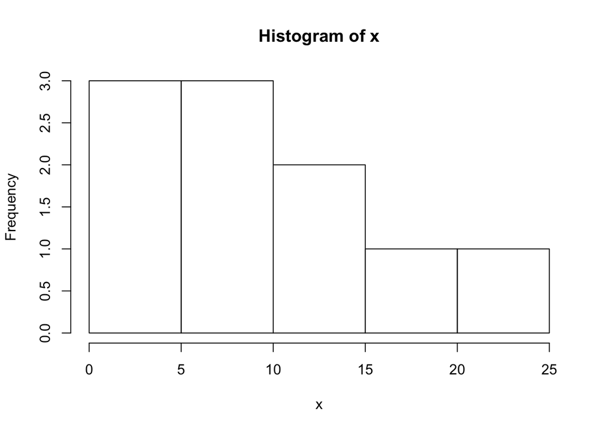

```r
hist(x)  # hist - from histogram
```

By default a histogram is white, but you can add a color:

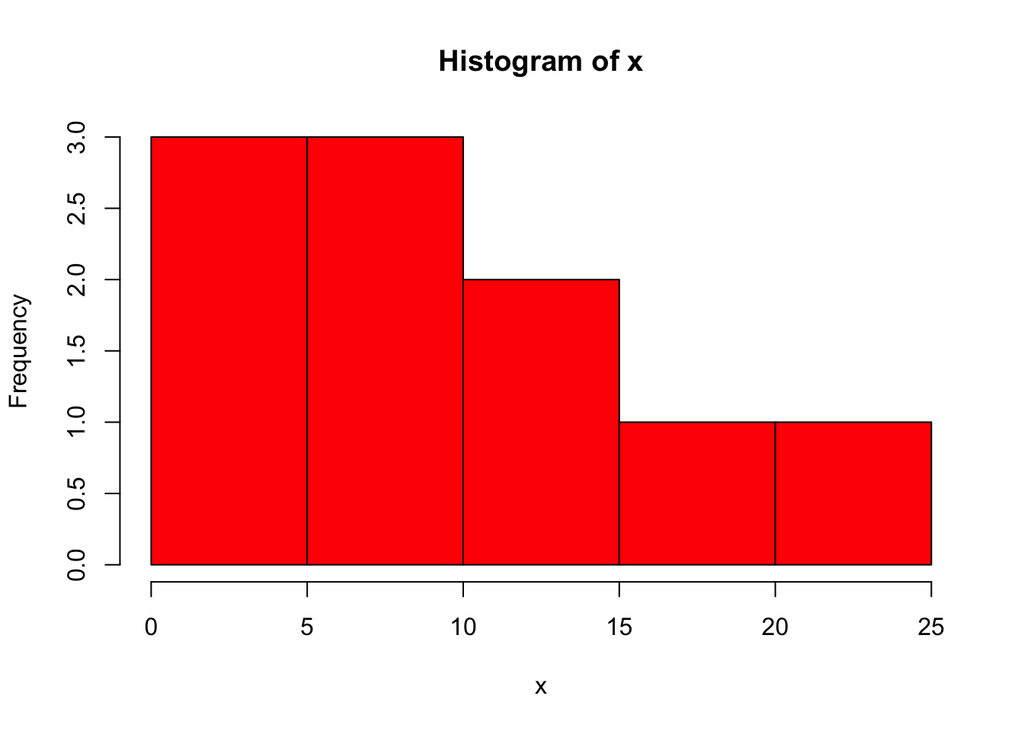

```r
hist(x, col="red")  # col for color
```

Or:

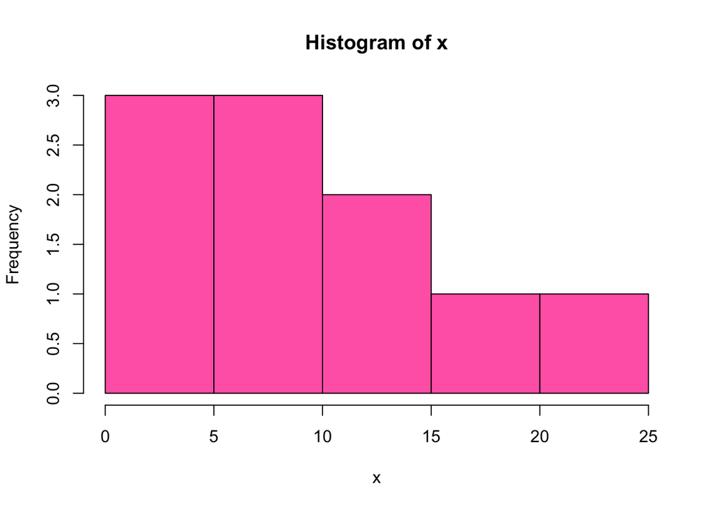

```r
hist(x, col="hotpink")  # more interesting color
```

There is a lot of colors in R, see the full list [here](http://www.stat.columbia.edu/~tzheng/files/Rcolor.pdf).

Now we will not focus on styling, we will discuss it later, but we should mention two points important from a statistical standpoint: setting different types of values by a vertical axis and choosing a different number of bins (rectangles in a histogram).

We can indicate normalised frequences by a vertical axis, i.e. values adjusted in such a way that a histogram has a total area of one.

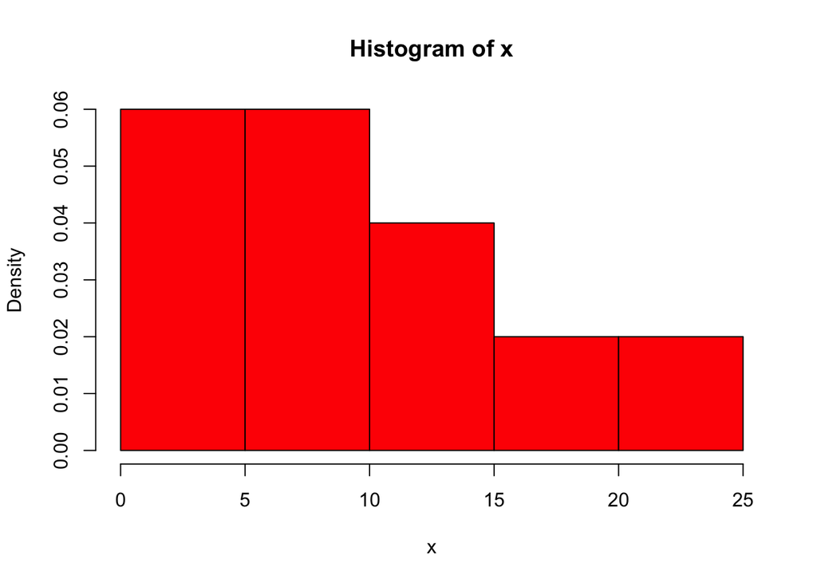

```r
# freq=FALSE, not absolute frequences by y-axis
hist(x, col="red", freq=FALSE)
```

So as to choose a number of rectangles in a histogram different from one set by default (if you are interested, read about [Sturges’ algorithm](https://en.wikipedia.org/wiki/Histogram#Sturges'_formula) or [other](https://www.rdocumentation.org/packages/grDevices/versions/3.5.1/topics/nclass) algorithms used in R) you can add a corresponding option:

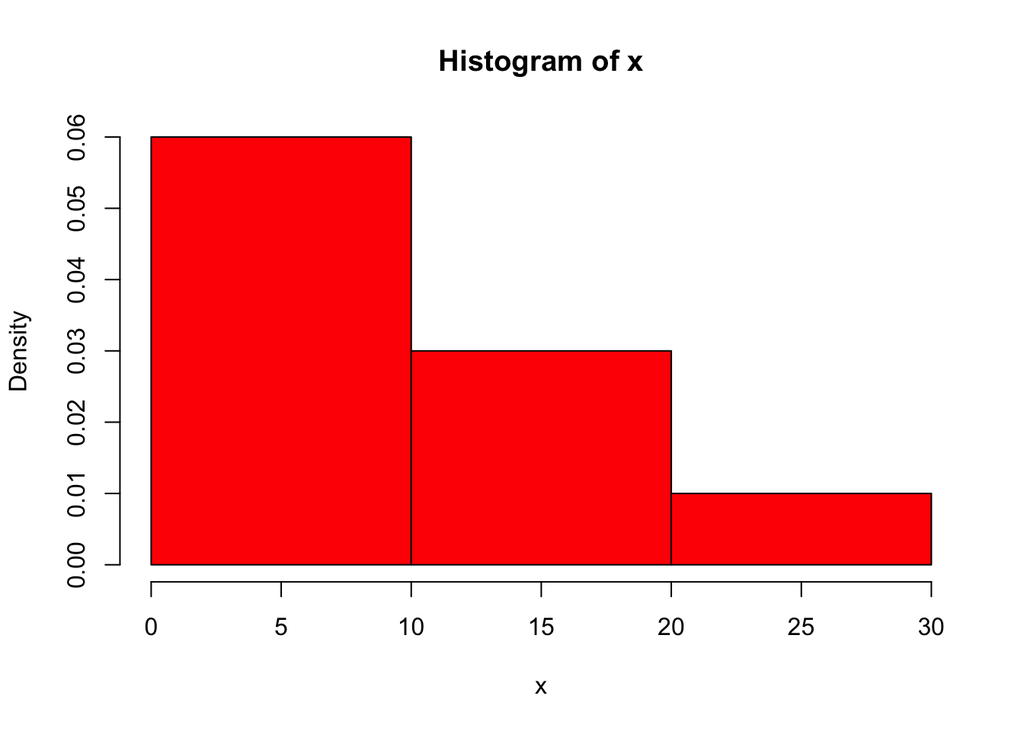

```r
hist(x, col="red", freq=FALSE, breaks=3)  # 3 bins
```

That is all for today. If you need something more, please, see the optional materials for this course.